# CRT Midterm

Tess Sameshima

Chris Ives

Rachael Latimer

4/25/2021

## Part A: Data

1. Use the function above to download all of the data from the 2014-15 to 2017-18 school years and bind it into a single data frame, using a single function (i.e., one line of code).
- Filter for only student groups coded as “White” or “Hispanic/Latino”.
- Select variables related to the number of students in each of the levels (1:4), and not percentages or collapsed levels.
- Remove any row that has missing data in any of the n variables

```r
#Run the code below to load the following dataset.
download_file <- function(year) {
  link <- glue::glue("https://www.oregon.gov/ode/educator-resources/assessment/TestResults20{year}/pagr_schools_ela_raceethnicity_{year-1}{year}.xlsx")
  rio::import(link, setclass = "tibble", na = c("-", "--", "*"))
}

#1.
data_1518 <- map_df(seq(15, 18, 1), download_file)

filtered <- data_1518 %>%
    clean_names() %>%
    filter(student_group == "White" | student_group == "Hispanic/Latino")

categories <- filtered %>%
  select(., academic_year, district, school, student_group, grade_level, number_level_4,
           number_level_3, number_level_2, number_level_1)

#pivot longer by number_level to "level"
cat_long <- categories %>%
  pivot_longer(cols = 6:9,
               names_to = "level",
               values_to = "n") %>%
  mutate(level = parse_number(level),
         level = as.character(level),
         n = as.integer(n)) %>%
  filter(n!="NA")

cat_long
```

```
## # A tibble: 90,576 x 7
##    academic_year district   school         student_group grade_level level     n
##    <chr>         <chr>      <chr>          <chr>         <chr>       <chr> <int>
##  1 2014-2015     Adrian SD… Adrian Elemen… Hispanic/Lat… Grade 3     4         1
##  2 2014-2015     Adrian SD… Adrian Elemen… Hispanic/Lat… Grade 3     3         2
##  3 2014-2015     Adrian SD… Adrian Elemen… Hispanic/Lat… Grade 3     2         1
##  4 2014-2015     Adrian SD… Adrian Elemen… Hispanic/Lat… Grade 3     1         2
##  5 2014-2015     Adrian SD… Adrian Elemen… Hispanic/Lat… Grade 6     4         0
##  6 2014-2015     Adrian SD… Adrian Elemen… Hispanic/Lat… Grade 6     3         2
##  7 2014-2015     Adrian SD… Adrian Elemen… Hispanic/Lat… Grade 6     2         3
##  8 2014-2015     Adrian SD… Adrian Elemen… Hispanic/Lat… Grade 6     1         2
##  9 2014-2015     Adrian SD… Adrian Elemen… Hispanic/Lat… Grade 7     4         0
## 10 2014-2015     Adrian SD… Adrian Elemen… Hispanic/Lat… Grade 7     3         2
## # … with 90,566 more rows
```

2. Sum the n across grades and school for each district within each academic year, student group, and level. Calculate the number of schools (unique schools listed) for each district. Also move your data to a wider format where the student groups become new columns, filled by the district n. Remove districts that did not report numbers for one or both student groups (i.e., drop missing data from the new columns).

```r
#2.



#this works but in slightly different order than example
d<- cat_long %>%
  group_by(district) %>%
  mutate(n_schools = length(unique(school)))

group_calc2 <- d %>%
    group_by(student_group, level, academic_year, district, n_schools) %>%
       summarize(total = sum(n)) %>%
    pivot_wider(names_from = student_group,
                values_from = total) %>%
   clean_names() %>%
  filter(hispanic_latino !="NA" & white!="NA")
```

## Part B: Achievement Gaps

1. Estimate the average achievement differences in terms of an effect size for every school district in the state that reported data on both student groups (i.e., using the data we created above), for each academic year. Conduct this analysis twice, once using group_by() %>% nest() map() and once using nest_by() %>% summarize().

```r
library(gapr)

m <- group_calc2 %>%
  group_by(district, academic_year) %>%
  nest() %>%
  mutate(v = map(data, ~estimate_v(.x, "hispanic_latino", "white"))) %>%
  unnest(v)
m2 <- group_calc2 %>%
  ungroup() %>%
  nest_by(district, academic_year) %>%
  summarize(v = list(estimate_v(data, "hispanic_latino", "white"))) %>%
  unnest(v)
```

2. Reproduce the plot to confirm that the estimates are equivalent across methods.

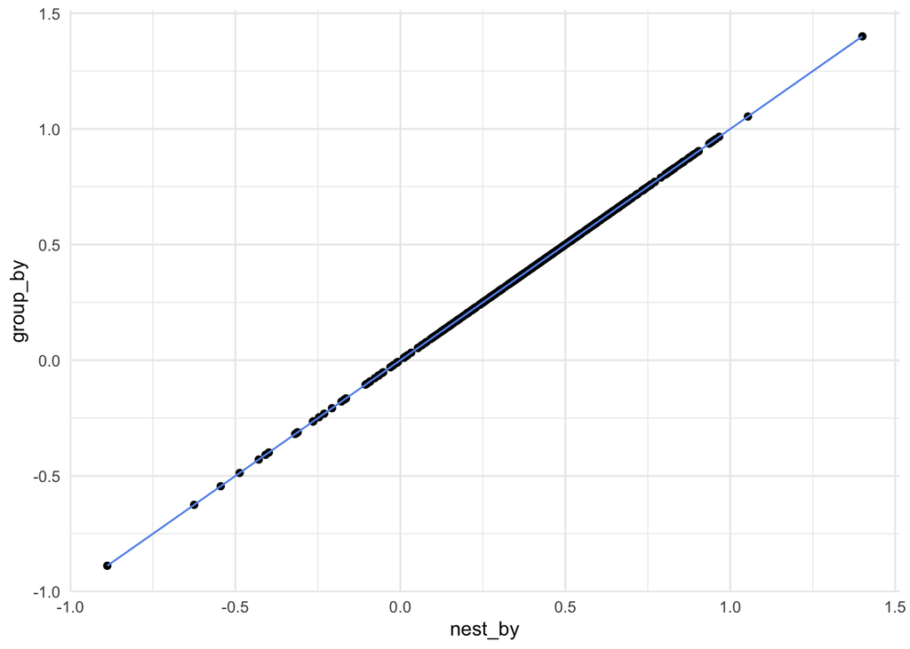

```r
m %>%
  rename(v1 = v) %>%
  left_join(m2) %>%
  rename(v2 = v) %>%
  ggplot(aes(v2, v1)) +
  geom_point() +
  geom_line(color = "cornflowerblue") +
  xlab("nest_by") +
  ylab("group_by") +
  theme_minimal()
```

3. The plot below shows the achievement difference estimates for one school district across years. Produce a similar plot to the below for each of the first 100 school districts. Once you’ve created all the plots, reproduce them again using an alternative method. Make sure you don’t miss the caption noting the number of schools in the district.

```r
library(glue)
```

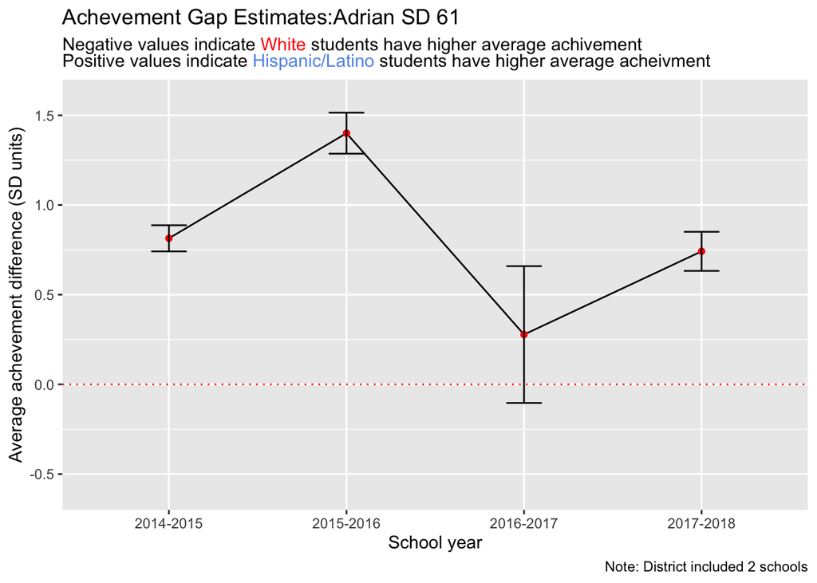

```r
library(ggtext)
library(dplyr)

#3.
#Filter for the frist 100 unique districts
dists <- unique(m$district)[1:100]

m_filter <- m %>%
  filter(district %in% dists)


# m_plot <- m_filter %>%
#   select(academic_year, district, v, v_se)

  #one plot
# m_plot %>% #group_by(district, academic_year) %>%
#   filter(district == "Adrian SD 61") %>%
#   ggplot(aes(academic_year, v, group = 1)) +
#   geom_line() +
#   geom_point(aes(color = v>0)) +
#   geom_errorbar(aes(ymin = v - v_se, ymax = v + v_se),
#                 width = 0.2) +
#   geom_hline(yintercept = 0, linetype = 'dotted', color = 'red') +
#   labs(title = glue("Achevement Gap Estimates:{m_plot$district}"),
#              y = "Average achevement difference (SD units)",
#              x = "School year")


#plot for all districts
    m_plot <-
      m_filter %>%
        group_by(district) %>%
          nest() %>%
            mutate(plot = map2(data, district, ~{
              ggplot(.x,
                     aes(academic_year, v, group = 1)) +
                geom_line() +
                geom_point(aes(color = v<0)) +
                geom_errorbar(aes(ymin = v - v_se, ymax = v + v_se),
                              width = 0.2) +
                geom_hline(yintercept = 0,
                           linetype = 'dotted',
                           color = 'red') +
                scale_color_manual(values = c("red", "cornflowerblue")) +
                scale_y_continuous(limits = c(-0.7, 1.7),
                                   expand = c(0,0))  +
                labs(title = glue("Achevement Gap Estimates:{.y}"),
                     subtitle = "Negative values indicate <span style='color:red;'>White</span> students have higher average achivement <br>Positive values indicate <span style='color:cornflowerblue;'>Hispanic/Latino</span> students have higher average acheivment", #<br> for element_markdown
                     caption = glue("Note: District included {(.x[[2]][[1]])[[2]][[1]]} schools"),
                     y = "Average achevement difference (SD units)",
                     x = "School year") +
                theme(legend.position = "none",
                plot.subtitle = element_markdown()) #necessary for colored lable characters
        }
          )
            )

#check
m_plot$plot[1]
```

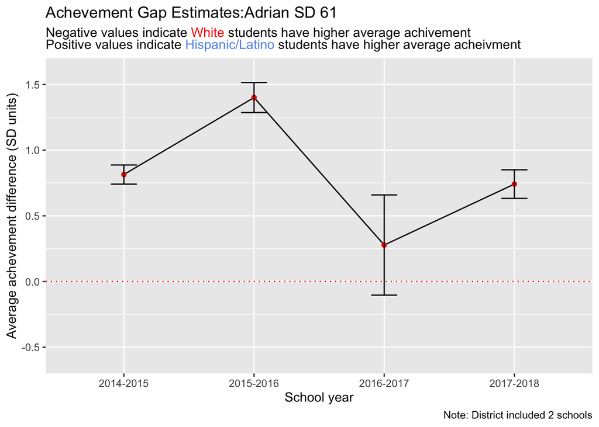

```r
#alt, rowwise
    m_plot2 <-
      m_filter %>%
      ungroup %>%
        nest_by(district) %>%
            mutate(plot = list(
              ggplot(data,
                     aes(academic_year, v, group = 1)) +
                geom_line() +
                geom_point(aes(color = v<0)) +
                geom_errorbar(aes(ymin = v - v_se, ymax = v + v_se),
                              width = 0.2) +
                geom_hline(yintercept = 0,
                           linetype = 'dotted',
                           color = 'red') +
                scale_color_manual(values = c("red", "cornflowerblue")) +
                scale_y_continuous(limits = c(-0.7, 1.7),
                                   expand = c(0,0))  +
                labs(title = glue("Achevement Gap Estimates:{district}"),
                     subtitle = "Negative values indicate <span style='color:red;'>White</span> students have higher average achivement <br>Positive values indicate <span style='color:cornflowerblue;'>Hispanic/Latino</span> students have higher average acheivment", #<br> for element markdown
                     caption = glue("Note: District included {(data[[2]][[1]])[[2]][[1]]} schools"),
                     y = "Average achevement difference (SD units)",
                     x = "School year") +
                theme(legend.position = "none",
                plot.subtitle = element_markdown())
          )
            )
#check
m_plot2$plot[1]
```

4.Save the plots into a “plots” directory. Make sure the file names are meaningful.

```r
#4.
#create directory
fs::dir_create(here::here("plots", "achievement-gap-estimates"))

#create file path
files <- str_replace_all(tolower(m_plot$district), " ", "-")
paths <- here::here("plots", "achievement-gap-estimates", glue("{files}.png"))
paths
```

```
##   [1] "/Users/tesufuai/Documents/Master/Spring 2021/EDLD653/EDLD653_midterm/plots/achievement-gap-estimates/adrian-sd-61.png"
##   [2] "/Users/tesufuai/Documents/Master/Spring 2021/EDLD653/EDLD653_midterm/plots/achievement-gap-estimates/amity-sd-4j.png"
##   [3] "/Users/tesufuai/Documents/Master/Spring 2021/EDLD653/EDLD653_midterm/plots/achievement-gap-estimates/ashland-sd-5.png"
##   [4] "/Users/tesufuai/Documents/Master/Spring 2021/EDLD653/EDLD653_midterm/plots/achievement-gap-estimates/astoria-sd-1.png"
##   [5] "/Users/tesufuai/Documents/Master/Spring 2021/EDLD653/EDLD653_midterm/plots/achievement-gap-estimates/athena-weston-sd-29rj.png"
##   [6] "/Users/tesufuai/Documents/Master/Spring 2021/EDLD653/EDLD653_midterm/plots/achievement-gap-estimates/baker-sd-5j.png"
##   [7] "/Users/tesufuai/Documents/Master/Spring 2021/EDLD653/EDLD653_midterm/plots/achievement-gap-estimates/bandon-sd-54.png"
##   [8] "/Users/tesufuai/Documents/Master/Spring 2021/EDLD653/EDLD653_midterm/plots/achievement-gap-estimates/banks-sd-13.png"
##   [9] "/Users/tesufuai/Documents/Master/Spring 2021/EDLD653/EDLD653_midterm/plots/achievement-gap-estimates/beaverton-sd-48j.png"
##  [10] "/Users/tesufuai/Documents/Master/Spring 2021/EDLD653/EDLD653_midterm/plots/achievement-gap-estimates/bend-lapine-administrative-sd-1.png"
##  [11] "/Users/tesufuai/Documents/Master/Spring 2021/EDLD653/EDLD653_midterm/plots/achievement-gap-estimates/bethel-sd-52.png"
##  [12] "/Users/tesufuai/Documents/Master/Spring 2021/EDLD653/EDLD653_midterm/plots/achievement-gap-estimates/brookings-harbor-sd-17c.png"
##  [13] "/Users/tesufuai/Documents/Master/Spring 2021/EDLD653/EDLD653_midterm/plots/achievement-gap-estimates/canby-sd-86.png"
##  [14] "/Users/tesufuai/Documents/Master/Spring 2021/EDLD653/EDLD653_midterm/plots/achievement-gap-estimates/cascade-sd-5.png"
##  [15] "/Users/tesufuai/Documents/Master/Spring 2021/EDLD653/EDLD653_midterm/plots/achievement-gap-estimates/centennial-sd-28j.png"
```

[output cut: 85 more lines]

```r
#adding paths to dataframe and saving
m_plot %>%
  ungroup() %>%
    mutate(path = paths) %>%
      rowwise() %>%
        summarize(
          ggsave(
            path,
            plot,
            width = 9.5,
            height = 6.5,
            dpi = 500
          )
        )
```

```
## geom_path: Each group consists of only one observation. Do you need to adjust
## the group aesthetic?
```

```
## `summarise()` has ungrouped output. You can override using the `.groups` argument.
```

```
## # A tibble: 100 x 0
```